# Evidencia 2

Daira Adriana Chavarría Rodríguez

2/5/2021

# Parte 1

**Link del video** (Youtube): https://youtu.be/tkVtY79LopE

# Parte 2

#### Investigación

Para la realización de la actividad se seleccionó la 2da opción, referente a la búsqueda de **secuencias de los coronavirus de otras especies, similares a SARS-CoV-2**.

#### Librerías

Se cargan las librerías necesarias para el correcto funcionamiento del código.

```r
library(ape)
library(ggplot2)
library(seqinr)
library(ggtree)
library(DECIPHER)
# Para poder alinear las secuencias de todos los virus
memory.limit(35000)
```

```
## [1] 35000
```

### Secuencias encontradas:

Las siguientes secuencias de nucleótidos fueron halladas en NCBI, y corresponden a diferentes especies animales como lo son:

- Murciélagos
- Pangolines
- Ratas
- Felinos
- Hurones
- Aves

Entre otros.

Asimismo, se incluye el número de acceso de cada una y su nombre abreviado como identificación. **La secuencia del SARS-Cov-2 se incluye igualmente**, a manera de referencia, y para poder comparar posteriormente.

```r
# Referencia
SARSCov2 <- read.fasta("SARSCov2.fasta", set.attributes = FALSE)
# Secuencias de otras especies (murciélago, hurón, felino...)
MurineHepatitis <- read.fasta("MurineHepatitis.fasta", set.attributes = FALSE)
PorcineEp <- read.fasta("PorcineEp.fasta", set.attributes = FALSE)
BelugaC <- read.fasta("BelugaC.fasta", set.attributes = FALSE)
RabbitC <- read.fasta("RabbitC.fasta", set.attributes = FALSE)
MinkC <- read.fasta("Mink.fasta", set.attributes = FALSE)
FerretC <- read.fasta("Ferret.fasta", set.attributes = FALSE)
AvianB <- read.fasta("AvianB.fasta", set.attributes = FALSE)
FelineP <- read.fasta("FelineP.fasta", set.attributes = FALSE)
BovineC <- read.fasta("Bovine.fasta", set.attributes = FALSE)
BatHKU4 <- read.fasta("BatHKU4.fasta", set.attributes = FALSE)
BatHKU5 <- read.fasta("BatHKU5.fasta", set.attributes = FALSE)
BatHKU9 <- read.fasta("BatHKU9.fasta", set.attributes = FALSE)
BatHKU2 <- read.fasta("BatHKU2.fasta", set.attributes = FALSE)
GooseC <- read.fasta("Goose.fasta", set.attributes = FALSE)
ShrewC <- read.fasta("Shrew.fasta", set.attributes = FALSE)
DuckC <- read.fasta("Duck.fasta", set.attributes = FALSE)
HedgehogC <- read.fasta("Hedgehog.fasta", set.attributes = FALSE)
RatC <- read.fasta("Rat.fasta", set.attributes = FALSE)
TurkeyC <- read.fasta("Turkey.fasta", set.attributes = FALSE)
BatHPBeta <- read.fasta("BatHp.fasta", set.attributes = FALSE)
Pangolin <- read.fasta("Pangolin.fasta", set.attributes = FALSE)

Nombres <- c("*SARS Cov2", "Murine hepatitis", "Porcine Diarrhea",
             "Beluga Whale", "Rabbit", "Mink", "Ferret", "Avian bronchitis",
             "Feline Peritonitis", "Bovine", "Bat HKU4", "Bat HKU5", "Bat HKU9",
             "Bat HKU2", "Goose", "Shrew", "Duck", "Hedgehog", "Rat", "Turkey",
             "Bat HP Beta", "Pangolin")

NamesAcc <- c("*SARS_Cov2", "Murine_hepatitis", "Porcine_Diarrhea",
             "Beluga_Whale_coronavirus", "Rabbit_coronavirus", "Mink_coronavirus",
             "Ferret_coronavirus", "Avian_bronchitis", "Feline_Peritonitis",
             "Bovine_coronavirus", "Bat_HKU4", "Bat_HKU5", "Bat_HKU9",
             "Bat_HKU2", "Goose_coronavirus", "Shrew_coronavirus",
             "Duck_coronavirus", "Hedgehog_coronavirus", "Rat_coronavirus",
             "Turkey_coronavirus", "Bat_HP_Beta", "Pangolin_coronavirus")

Accessions <- c("NC_045512", "NC_048217", "NC_003436", "NC_010646", "NC_017083",
                "NC_023760", "NC_030292", "NC_001451", "NC_002306", "NC_003045",
                "NC_009019", "NC_009020", "NC_009021", "NC_009988", "NC_046965",
                "NC_048211", "NC_048214", "NC_039207", "NC_032730", "NC_010800",
                "NC_025217", "MT121216")

fancyPrint <- function (sequences){
  i <- 1
  while (i <= length(sequences)){
    print(paste("Variante", Variantes[i]," encontrada en", Countries[i], ":"))
    print(head((sequences[[i]][[1]])))
    print(tail((sequences[[i]][[1]])))
    i <- i + 1
  }
}

MySequences <- c(SARSCov2, MurineHepatitis, PorcineEp, BelugaC, RabbitC, MinkC,
                 FerretC, AvianB, FelineP, BovineC, BatHKU4, BatHKU5, BatHKU9,
                 BatHKU2, GooseC, ShrewC, DuckC, HedgehogC, RatC, TurkeyC,
                 BatHPBeta, Pangolin)
```

### Tamaño de las secuencias:

Por medio de una función para obtener el tamaño de cada una de nuestras secuencias, así como de otra función para imprimirlas en un formato entendible/atractivo; se resuelve esta parte de la evidencia. Se verificó que el tamaño fuera el mismo que el declarado en NCBI para cada secuencia.

```r
getSize <- function(sequence){
  return (length(sequence[[1]]))
}
fancySize <- function(sequences){
  i <- 1
  while (i <= length(sequences)){
    print(paste("El tamaño del virus (coronavirus)", Nombres[i], "es de:", getSize(sequences[i])))
    i<- i+1
  }
}

fancySize(MySequences)
```

```
## [1] "El tamaño del virus (coronavirus) *SARS Cov2 es de: 29903"
## [1] "El tamaño del virus (coronavirus) Murine hepatitis es de: 31335"
## [1] "El tamaño del virus (coronavirus) Porcine Diarrhea es de: 28033"
## [1] "El tamaño del virus (coronavirus) Beluga Whale es de: 31686"
## [1] "El tamaño del virus (coronavirus) Rabbit es de: 31100"
## [1] "El tamaño del virus (coronavirus) Mink es de: 28941"
## [1] "El tamaño del virus (coronavirus) Ferret es de: 28434"
## [1] "El tamaño del virus (coronavirus) Avian bronchitis es de: 27608"
## [1] "El tamaño del virus (coronavirus) Feline Peritonitis es de: 29355"
## [1] "El tamaño del virus (coronavirus) Bovine es de: 31028"
## [1] "El tamaño del virus (coronavirus) Bat HKU4 es de: 30286"
## [1] "El tamaño del virus (coronavirus) Bat HKU5 es de: 30482"
## [1] "El tamaño del virus (coronavirus) Bat HKU9 es de: 29114"
## [1] "El tamaño del virus (coronavirus) Bat HKU2 es de: 27165"
## [1] "El tamaño del virus (coronavirus) Goose es de: 28539"
## [1] "El tamaño del virus (coronavirus) Shrew es de: 25984"
## [1] "El tamaño del virus (coronavirus) Duck es de: 27754"
## [1] "El tamaño del virus (coronavirus) Hedgehog es de: 30148"
## [1] "El tamaño del virus (coronavirus) Rat es de: 28763"
## [1] "El tamaño del virus (coronavirus) Turkey es de: 27657"
## [1] "El tamaño del virus (coronavirus) Bat HP Beta es de: 31491"
## [1] "El tamaño del virus (coronavirus) Pangolin es de: 29521"
```

## Gráficas:

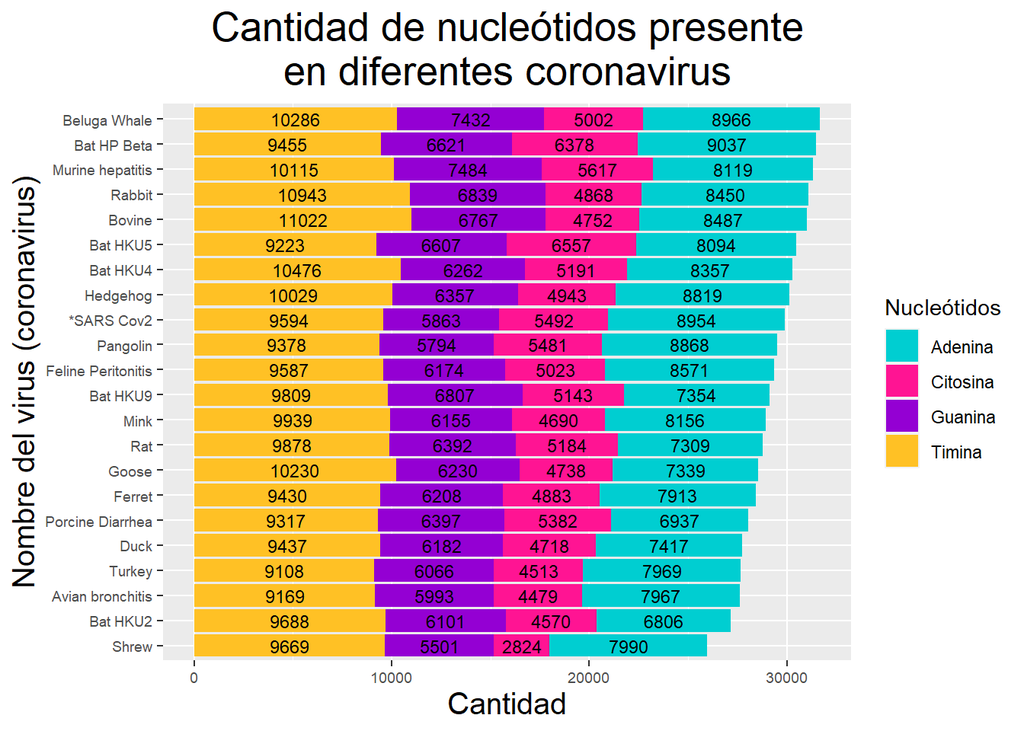

*(Se verificó que no existieran nucleótidos desconocidos “N” en ninguna de las secuencias)*

Se ordenan las secuencias de mayor a menor cantidad (total) de nucleótidos. Por ello podemos decir que la secuencia más larga pertenece al coronavirus relativo a la beluga (beluga whale), y la secuencia más corta pertenece al coronavirus relativo a la musaraña (shrew).

A diferencia de la comparación hecha entre algunas *variantes de SARS-CoV-2* y el mismo virus, al comparar *diferentes tipos de coronavirus pertenecientes a varias especies de animales* vemos que existe una diferencia muy notable entre sí. Por ejemplo, son muy diferentes las secuencias del coronavirus de la musaraña y el coronavirus de la beluga.

Sin embargo, existen algunos virus que se parecen más entre sí, como lo es el caso del conejo y el bovino. Sus secuencias tienen un total de nucleótidos muy similar, así como el porcentaje de cada uno de estos (Adenina, Guanina, Citosina, Timina).

### Árbol filogenético:

[output not shown]

[output not shown]

[output cut: 41 more lines]

```
## DNAStringSet object of length 22:
##      width seq                                              names
##  [1] 29903 ATTAAAGGTTTATACCTTCCCAG...AAAAAAAAAAAAAAAAAAAAAA NC_045512
##  [2] 31335 GTATAAGAGTGATTGGCGTCCGT...CATGGCCAATTGGAAGAATCAC NC_048217
##  [3] 28033 ACTTAAAAAGATTTTCTATCTAC...GACGGTGTTGATATGGATACAC NC_003436
##  [4] 31686 CTATTTGTGAATAATATATATAT...AAAAAAAAAAAAAAAAAAAAAA NC_010646
##  [5] 31100 GATTCTGAGCGATTTGCGTGCGT...AATCACAAAAAAAAAAAAAAAA NC_017083
##  ...   ... ...
## [18] 30148 GATTAAAGAGAATAGCATAGCTA...GATGATTTGCAAAAAAAAAAAA NC_039207
## [19] 28763 ACTTTTAGAGTATAATCTATTAT...AAAAAAAAAAAAAAAAAAAAAA NC_032730
## [20] 27657 ACTTAAGATAGATATTAATATAT...AAAAAAAAAAAAAAAAAAAAAA NC_010800
## [21] 31491 TTAAGCTTCGGCTTGTTGCATAG...TAGTAGAATTGCAAAAAAAAAA NC_025217
## [22] 29521 CACGCAGTATAATTAATAACTAA...AGAGCCACCACATTTTCACCGA MT121216
```

[output not shown]

[output not shown]

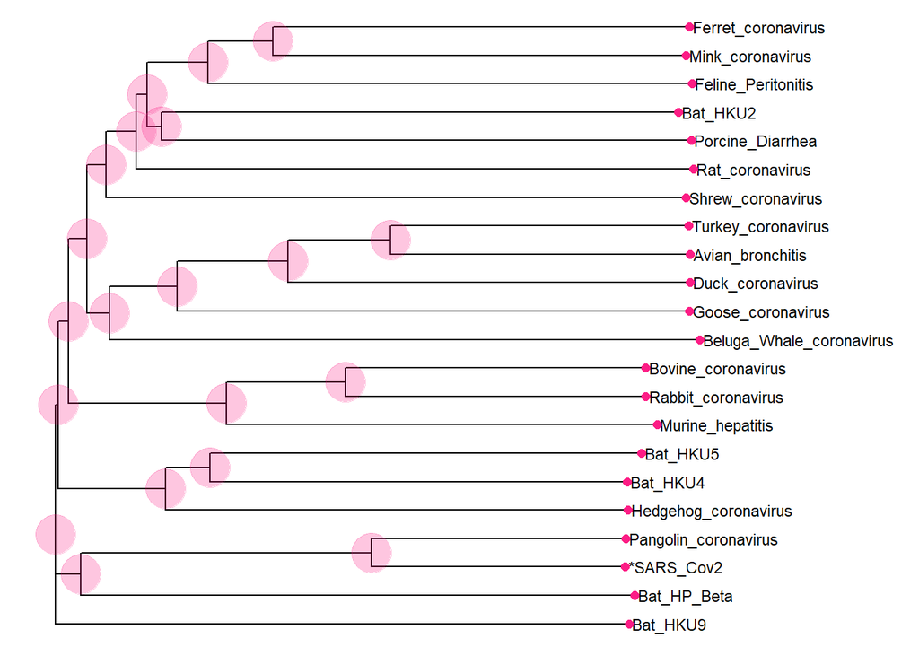

Podemos notar la distancia existente entre cada una de los coronavirus, siendo que el más cercano al SARS-CoV-2 (el más similar) es el **coronavirus del pangolín (Acceso: MT121216)**, siendo que ambos se derivan de un mismo nodo. Asimismo, el **betacoronavirus del murciélago (Bat_HP_Beta)** se deriva del mismo nodo que los ambos anteriormente mencionados, siendo que es más cercano a ellos que otros virus.

## Zoonosis:

Todo lo que se ha mencionado con anterioridad nos ayuda a entender el fenómeno de **zoonosis**.

**¿Qué es la Zoonosis?** Es la transmisión de enfermedades infecciosas desde animales hacia el ser humano. Su inversa es la antropozoonosis, cuando el humano contagia a otros animales.

A pesar de que existan múltiples teorías sobre el origen del COVID-19 (*haber sido creado en un laboratorio*), podemos respaldar con experimentos como el presente que el SARS-CoV-2 tuviera un **origen zoonico**, como el 70% de las infecciones emergentes de los últimos 40 años.

En nuestro árbol filogenético notamos que el virus más parecido al SARS-CoV-2 pertenece al *pangolín*, lo que concuerda con las hipótesis (de origen científico) que se nos han planteado hasta el momento:

*“[…] las investigaciones apuntan a que el animal era un murciélago que transmitió el virus a otro animal intermedio, con toda seguridad un pangolín […] que lo transmitió hasta los humanos”* Peinado Lorca M. (2021)

Dado que el betacoronavirus del murciélago (Bat_HP_Beta) es cercano a las secuencias del virus perteneciente al pangolín y al COVID-19, pero no tan cercano como estas últimas entre sí, podemos deducir que la zoonosis no fue directa, es decir que el murciélago en cuestión pudo transmitir el virus al pangolín, y el pangolín al humano. Esto concuerda nuevamente con las hipótesis más fiables.

Otras teorías también afirman la posibilidad de que la zoonosis fuera directa hacia el humano (murciélago-humano). Esto es posible, aunque la hipótesis anteriormente mencionada resulta ser más posible.

## Referencias:

- WebMD (2021). “How Many Coronavirus Strains Are There?”. Recuperado el 27 de abril del 2021 desde: https://www.webmd.com/lung/coronavirus-strains#1

### Secuencias (NCBI)

- NCBI (2020). “Murine hepatitis virus strain A59, complete genome”. Recuperado el 27 de abril del 2021 desde: https://www.ncbi.nlm.nih.gov/nuccore/NC_048217
- NCBI (2018). “Porcine epidemic diarrhea virus, complete genome”. Recuperado el 27 de abril del 2021 desde: https://www.ncbi.nlm.nih.gov/nuccore/NC_003436
- NCBI (2020). “Beluga Whale coronavirus SW1, complete genome”. Recuperado el 27 de abril del 2021 desde: https://www.ncbi.nlm.nih.gov/nuccore/NC_010646
- NCBI (2020). “Rabbit coronavirus HKU14, complete genome”. Recuperado el 27 de abril del 2021 desde: https://www.ncbi.nlm.nih.gov/nuccore/NC_017083
- NCBI (2018). “Mink coronavirus strain WD1127, complete genome”. Recuperado el 27 de abril del 2021 desde: https://www.ncbi.nlm.nih.gov/nuccore/NC_023760
- NCBI (2018). “Ferret coronavirus isolate FRCoV-NL-2010, complete genome”. Recuperado el 27 de abril del 2021 desde: https://www.ncbi.nlm.nih.gov/nuccore/NC_030292
- NCBI (2018). “Avian infectious bronchitis virus, complete genome”. Recuperado el 27 de abril del 2021 desde: https://www.ncbi.nlm.nih.gov/nuccore/NC_001451
- NCBI (2018). “Feline infectious peritonitis virus, complete genome”. Recuperado el 27 de abril del 2021 desde: https://www.ncbi.nlm.nih.gov/nuccore/NC_002306
- NCBI (2020). “Bovine coronavirus isolate BCoV-ENT, complete genome”. Recuperado el 27 de abril del 2021 desde: https://www.ncbi.nlm.nih.gov/nuccore/NC_003045
- NCBI (2020). “Tylonycteris bat coronavirus HKU4, complete genome”. Recuperado el 27 de abril del 2021 desde: https://www.ncbi.nlm.nih.gov/nuccore/NC_009019
- NCBI (2020). “Pipistrellus bat coronavirus HKU5, complete genome”. Recuperado el 27 de abril del 2021 desde: https://www.ncbi.nlm.nih.gov/nuccore/NC_009020
- NCBI (2020). “Rousettus bat coronavirus HKU9, complete genome”. Recuperado el 27 de abril del 2021 desde: https://www.ncbi.nlm.nih.gov/nuccore/NC_009021
- NCBI (2018). “Bat coronavirus HKU2, complete genome”. Recuperado el 27 de abril del 2021 desde: https://www.ncbi.nlm.nih.gov/nuccore/NC_009988
- NCBI (2020). “Canada goose coronavirus strain Cambridge_Bay_2017, complete genome”. Recuperado el 27 de abril del 2021 desde: https://www.ncbi.nlm.nih.gov/nuccore/NC_046965
- NCBI (2020). “Wencheng Sm shrew coronavirus isolate Xingguo-74 ORF1ab polyprotein, spike glycoprotein, envelope protein, membrane protein, and nucleocapsid protein genes, complete cds”. Recuperado el 27 de abril del 2021 desde: https://www.ncbi.nlm.nih.gov/nuccore/NC_048211
- NCBI (2020). “Duck coronavirus isolate DK/GD/27/2014, complete genome”. Recuperado el 27 de abril del 2021 desde: https://www.ncbi.nlm.nih.gov/nuccore/NC_048214
- NCBI (2020). “Betacoronavirus Erinaceus/VMC/DEU/2012 isolate ErinaceusCoV/2012-174/GER/2012, complete genome”. Recuperado el 27 de abril del 2021 desde: https://www.ncbi.nlm.nih.gov/nuccore/NC_039207
- NCBI (2020). “Lucheng Rn rat coronavirus isolate Lucheng-19, complete genome”. Recuperado el 27 de abril del 2021 desde: https://www.ncbi.nlm.nih.gov/nuccore/NC_032730
- NCBI (2020). “Turkey coronavirus, complete genome”. Recuperado el 27 de abril del 2021 desde: https://www.ncbi.nlm.nih.gov/nuccore/NC_010800
- NCBI (2020). “Bat Hp-betacoronavirus/Zhejiang2013, complete genome”. Recuperado el 27 de abril del 2021 desde: https://www.ncbi.nlm.nih.gov/nuccore/NC_025217
- NCBI (2020). “Pangolin coronavirus isolate MP789, complete genome”. Recuperado el 2 de mayo del 2021 desde: https://www.ncbi.nlm.nih.gov/nuccore/MT121216 ### Zoonosis
- OMS (s.f.). “Zoonosis y Medio Ambiente”. Recuperado el 1 de mayo del 2021 desde: https://www.who.int/foodsafety/areas_work/zoonose/es/#:~:text=Las%20enfermedades%20zoonóticas%20son%20un,animales%20a%20los%20seres%20humanos.
- Sabatés R. (2017). “Zoonosis - Definición y ejemplos”. Recuperado el 2 de mayo del 2021 desde: https://www.expertoanimal.com/zoonosis-definicion-y-ejemplos-21846.html
- Peinado Lorca M. (2021). “Murciélagos y pangolines: el coronavirus es una zoonosis, no un producto de laboratorio”. Recuperado el 2 de mayo del 2021 desde: https://theconversation.com/murcielagos-y-pangolines-el-coronavirus-es-una-zoonosis-no-un-producto-de-laboratorio-135753